# Mapping census block groups

Steve Simon

Created on 2021-09-22

```r
library(sf)
library(tidyverse)
```

You can find shapefiles for census block groups at [the U.S. Census website](https://www.census.gov/geographies/mapping-files/time-series/geo/cartographic-boundary.html)

The census files use a shapefile format. This is a rather complex system with at least three separate files constituting the shapefile. You can find a nice introduction at the [Wikipedia page on shapefiles](https://en.wikipedia.org/wiki/Shapefile).

The st_read function is part of the sf library. It reads a shape file and converts it to an sf object. An sf (simple features object) is a data frame where the last column is a list-column, an sfc object.

The list column represents geographic features either as a single data points (POINT), multiple data points (MULITPOINT), a two-dimensional path (LINESTRING), multiple paths (MULTILINESTRING), a polygon (POLYGON), or multiple polygons (MULTIPOLYGON).

The POLYGON and MULTIPOLYGON features can include holes, and there are complex rules for geographic features with holes.

```r
path_name <- "../data"
list.files(path_name)
```

```
##  [1] "cb_2017_us_zcta510_500k.cpg"
##  [2] "cb_2017_us_zcta510_500k.dbf"
##  [3] "cb_2017_us_zcta510_500k.prj"
##  [4] "cb_2017_us_zcta510_500k.shp"
##  [5] "cb_2017_us_zcta510_500k.shp.ea.iso.xml"
##  [6] "cb_2017_us_zcta510_500k.shp.iso.xml"
##  [7] "cb_2017_us_zcta510_500k.shp.xml"
##  [8] "cb_2017_us_zcta510_500k.shx"
##  [9] "cb_2020_29_bg_500k.cpg"
## [10] "cb_2020_29_bg_500k.dbf"
## [11] "cb_2020_29_bg_500k.prj"
## [12] "cb_2020_29_bg_500k.shp"
## [13] "cb_2020_29_bg_500k.shp.ea.iso.xml"
## [14] "cb_2020_29_bg_500k.shp.iso.xml"
## [15] "cb_2020_29_bg_500k.shx"
```

[output cut: 39 more lines]

```r
file_name <- "tl_2020_29_tabblock20.shp"
path_name                              %>%
  paste(file_name, sep="/")            %>%
  st_read(stringsAsFactors=FALSE)      -> all_census_blocks
```

The sf object looks and acts like an ordinary data frame. But the last column is quite unusual.

```r
names(all_census_blocks)
```

```
##  [1] "STATEFP20"  "COUNTYFP20" "TRACTCE20"  "BLOCKCE20"  "GEOID20"
##  [6] "NAME20"     "MTFCC20"    "UR20"       "UACE20"     "UATYPE20"
## [11] "FUNCSTAT20" "ALAND20"    "AWATER20"   "INTPTLAT20" "INTPTLON20"
## [16] "geometry"
```

```r
head(all_census_blocks)
```

```
## Simple feature collection with 6 features and 15 fields
## geometry type:  POLYGON
## dimension:      XY
## bbox:           xmin: -93.55058 ymin: 36.85803 xmax: -93.13018 ymax: 37.08191
## geographic CRS: NAD83
##   STATEFP20 COUNTYFP20 TRACTCE20 BLOCKCE20         GEOID20     NAME20 MTFCC20
## 1        29        043    020401      1101 290430204011101 Block 1101   G5040
## 2        29        043    020102      3017 290430201023017 Block 3017   G5040
## 3        29        043    020502      1033 290430205021033 Block 1033   G5040
## 4        29        043    020502      1064 290430205021064 Block 1064   G5040
## 5        29        043    020101      1026 290430201011026 Block 1026   G5040
## 6        29        043    020101      2035 290430201012035 Block 2035   G5040
##   UR20 UACE20 UATYPE20 FUNCSTAT20 ALAND20 AWATER20  INTPTLAT20   INTPTLON20
## 1 <NA>   <NA>     <NA>          S   68306        0 +37.0496763 -093.1327337
## 2 <NA>   <NA>     <NA>          S    4667        0 +37.0816832 -093.4217277
## 3 <NA>   <NA>     <NA>          S   46391        0 +36.9123974 -093.2532787
## 4 <NA>   <NA>     <NA>          S 3727694        0 +36.8681498 -093.1949506
## 5 <NA>   <NA>     <NA>          S   24211        0 +37.0678956 -093.5492493
## 6 <NA>   <NA>     <NA>          S 3089802     1676 +37.0307446 -093.5309477
##                         geometry
## 1 POLYGON ((-93.13462 37.0487...
## 2 POLYGON ((-93.42291 37.0818...
## 3 POLYGON ((-93.25524 36.9104...
## 4 POLYGON ((-93.20799 36.8678...
## 5 POLYGON ((-93.55058 37.0676...
## 6 POLYGON ((-93.53707 37.0254...
```

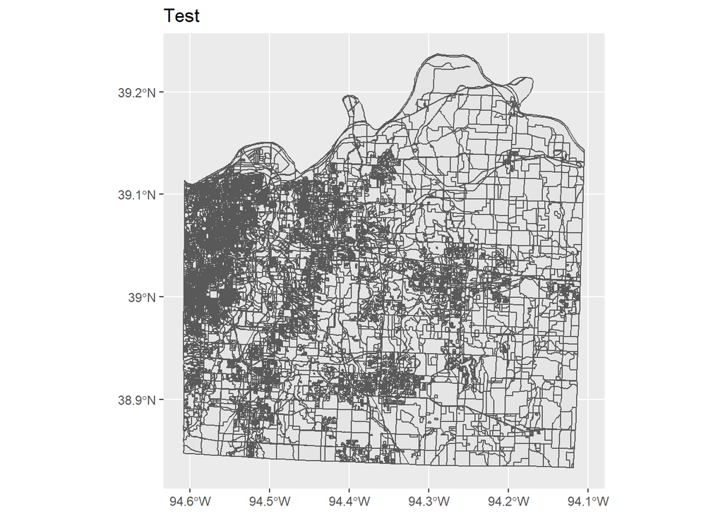

```r
all_census_blocks                          %>%
  filter(COUNTYFP20=="095") %>%
  ggplot()                              +
  geom_sf(aes())                 +
  ggtitle("Test")
```

Save everything for possible later use.

```r
save.image("../data/census-block-example.RData")
```